# E - Intmap Analyse

Denis Feuerstein

2024-02-02

## 1 Einführung

Dieses Skript dient der Analyse des Probelaufs, welcher am 15.02 mit E durchgeführt wurde. Vorrangig soll dabei die Struktur der Intmap und ihre Effizienz in den Dimensionen Zeit und Raum untersucht werden.

```
## 'data.frame':    4727 obs. of  16 variables:
##  $ Problem     : chr  "AGT012+2.p" "AGT023+1.p" "AGT023+2.p" "AGT026+1.p" ...
##  $ Status      : chr  "U" "U" "U" "U" ...
##  $ Reason      : chr  "maxres" "maxres" "maxres" "maxres" ...
##  $ EmptyInvoked: int  12569 24839 20460 15501 17571 22313 25907 25644 25272 15541 ...
##  $ IntInvoked  : int  128182 273674 227995 151684 178005 239936 289068 286100 283587 159041 ...
##  $ ArrayInvoked: int  2580 2390 2548 2086 2624 2580 2437 2428 2782 2608 ...
##  $ TreeInvoked : int  187 112 127 202 108 100 120 121 110 190 ...
##  $ MapDeleted  : int  16075 13406 16566 12892 15887 16411 13432 13432 16617 16193 ...
##  $ EmptyDeleted: int  15520 13071 16008 12560 15342 15853 13100 13100 16062 15636 ...
##  $ IntDeleted  : int  0 0 0 0 0 0 0 0 0 0 ...
##  $ ArrayDeleted: int  37 27 40 26 39 40 25 26 38 39 ...
##  $ TreeDeleted : int  518 308 518 306 506 518 307 306 517 518 ...
##  $ IntmapItems : num  143518 301015 251130 169473 198308 ...
##  $ UserTime    : num  59.9 59.8 59.9 59.9 59.9 ...
##  $ SystemTime  : num  0.092 0.288 0.108 0.096 0.1 0.1 0.104 0.184 0.152 0.18 ...
##  $ TotalTime   : num  60 60.1 60.1 60 60 ...
```

```
##    Problem             Status             Reason           EmptyInvoked
##  Length:4727        Length:4727        Length:4727        Min.   :     4
##  Class :character   Class :character   Class :character   1st Qu.:   633
##  Mode  :character   Mode  :character   Mode  :character   Median :  3746
##                                                           Mean   :  9481
##                                                           3rd Qu.: 10559
##                                                           Max.   :416267
##                                                           NA's   :343
##    IntInvoked      ArrayInvoked    TreeInvoked        MapDeleted
##  Min.   :     0   Min.   :    0   Min.   :    0.0   Min.   :     0
##  1st Qu.:  7654   1st Qu.:  962   1st Qu.:  188.8   1st Qu.:  1436
##  Median : 28231   Median : 2888   Median :  860.0   Median :  5816
##  Mean   : 66228   Mean   : 3880   Mean   : 2210.1   Mean   : 18606
##  3rd Qu.: 80236   3rd Qu.: 5243   3rd Qu.: 2916.2   3rd Qu.: 15906
##  Max.   :940480   Max.   :53975   Max.   :27692.0   Max.   :522221
##  NA's   :343      NA's   :343     NA's   :343       NA's   :343
##   EmptyDeleted      IntDeleted   ArrayDeleted     TreeDeleted
##  Min.   :     0   Min.   :0     Min.   :   0.0   Min.   :   0.0
##  1st Qu.:  1396   1st Qu.:0     1st Qu.:   6.0   1st Qu.:  23.0
##  Median :  5650   Median :0     Median :  32.0   Median :  94.0
##  Mean   : 18058   Mean   :0     Mean   : 141.9   Mean   : 406.0
##  3rd Qu.: 15382   3rd Qu.:0     3rd Qu.: 148.0   3rd Qu.: 424.2
##  Max.   :521513   Max.   :0     Max.   :3589.0   Max.   :9098.0
##  NA's   :343      NA's   :343   NA's   :343      NA's   :343
##   IntmapItems        UserTime        SystemTime       TotalTime
##  Min.   :     6   Min.   :  0.00   Min.   :0.0000   Min.   :  0.004
##  1st Qu.: 13036   1st Qu.: 58.79   1st Qu.:0.2960   1st Qu.: 59.982
##  Median : 37773   Median : 59.02   Median :0.9510   Median : 60.017
##  Mean   : 81798   Mean   : 51.65   Mean   :0.7974   Mean   : 52.447
##  3rd Qu.:106262   3rd Qu.: 59.64   3rd Qu.:1.1190   3rd Qu.: 60.078
##  Max.   :959690   Max.   :277.92   Max.   :3.5690   Max.   :279.786
##  NA's   :343      NA's   :1101     NA's   :1101     NA's   :1101
```

## 2 Bewertung des Probelaufs

Im Folgenden eine Untersuchung der Ergebnisse des Probelaufs. Dafür soll zunächst betrachtet werden, wie die Verarbeitung durchlaufen wurde und ob vlt. einige Probleme nicht durchlaufen wurden. Als Quelle dient hierfür die nohup.out-Datei, welche beim Probelauf angelegt wurde. Diese wurde dahingehend bearbeitet, als das die Ausgaben früherer Probeläufe entfernt wurden. In früheren Probelaufen waren auch noch Probleme enthalten, welche in einer Logik höherer Stufe definiert waren und erst durch eine Rekompilierung von E lösbar gewesen wären. Dies Betraf 820 Probleme, welche entfernt wurden.

Beim Überfliegen der Datei fiel auf, dass in einigen Fällen E die Verarbeitung mehrerer Probleme aus verschiedenen Gründen abbrechen musste. Dabei wurden folgende Gründe identifiziert:

1. Dass es Fehler bei der Typisierung gab (dies betraf 148 Probleme)
2. Dass die zulässige Speichergröße Überschritten wurde (dies betraf 65 Probleme)
3. Dass das Zeitlimit überschritten wurde (dies betraf 15 Probleme)

Diese konnten also nicht bearbeitet werden und bei Ihnen wurde deshalb die weitere Verarbeitung abgebrochen. Bei den Problemen, die aber bearbeitet wurden, gab ein beachtlicher Anteil keine Rückgabewerte. Dies verrät ein Blick in die Dateien mit den common_stats und auch ein Vergleich der Dateigrößen der einzelnen Problemdateien. Für 7 Problemdomänen (GEG, HWC, LIN, PHI, PRD, QUA und RAL) wurden vom Python-Skript (leere) CSV-Dateien angelegt, weil diese keine Probleme mit den gesuchten Härtegrad verfügen. Bei einem ersten Probelauf waren viele Problemdateien leer - insgesamt 1.593. Diese Zahl konnte durch einige Anpassungen (Laufgeschwindigkeit für das Problem, Begrenzung auf Probleme der FOF) auf etwa ein Viertel reduziert werden - 393 Probleme lieferten leere CSV-Dateien.

Eine Untersuchung der Spalte Reason für alle bearbeitetn Probleme gibt dabei folgende Verteilung:

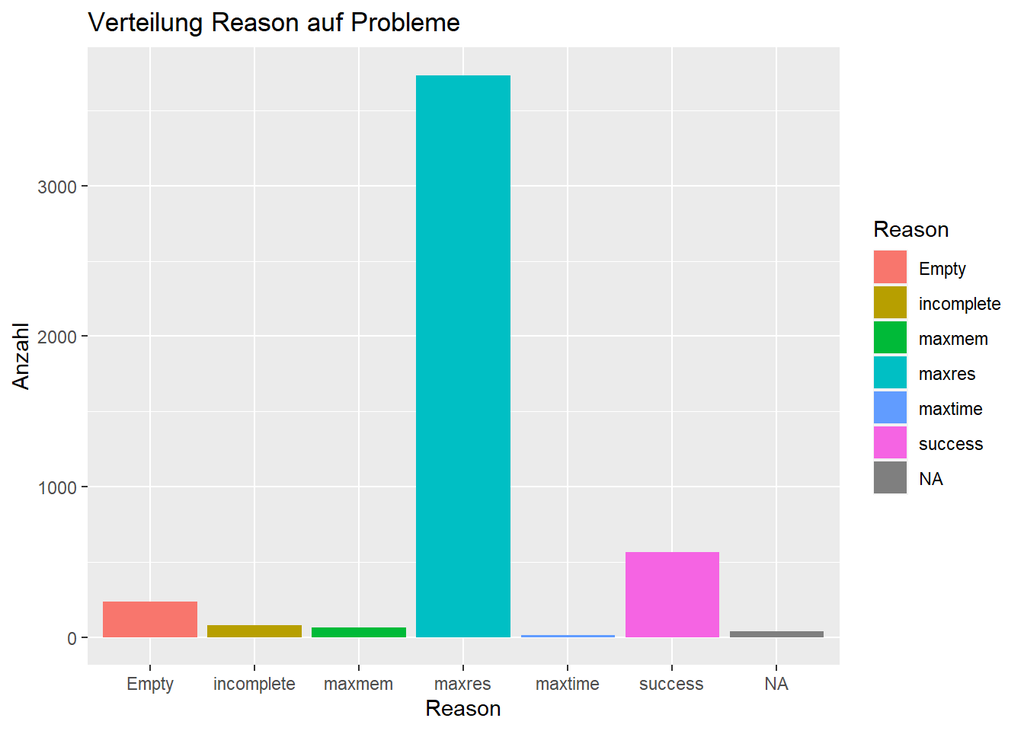

Von 4727 bearbeiteten Problemen waren:

Ohne Rückgabe: 234

NA: 36

Unvollständig:78

Maximalen Speicher: 65

Maximale Ressourcen: 3735

Maximale Ausführungszeit: 15

Erfolgreich: 564

Für einen vorhergehenden Versuch mit soft-CPU-Limit=30 war die Anzahl für erfolgreich durchlaufene Problembearbeitungen nur halb so groß.

Folgt man dieser Verteilung, so ist leicht anzunehmen, dass ein Großteil der leeren Dateien auf Empty/ (als ohne Rückgabewert) und NA (ohne Angabe) entfallen wird.

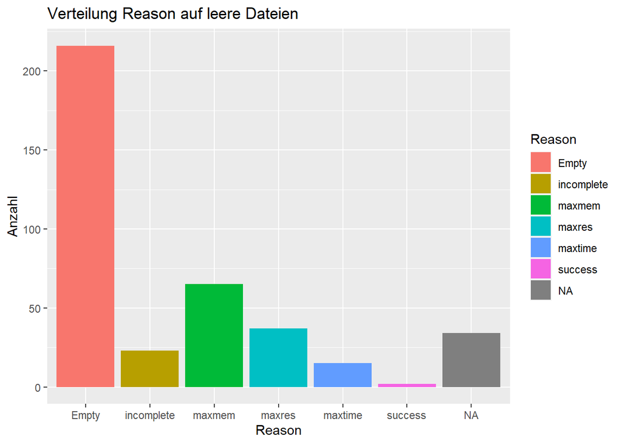

Dabei verteilen sich die Werte auf die 393 leeren CSV-Dateien wie folgt:

Ohne Rückgabe: 216

NA: 34

Unvollständig:23

Maximalen Speicher: 65

Maximale Ressourcen: 37

Maximale Ausführungszeit: 15

In nur zwei Fällen (Maximalen Speicher und Maximale Ausführungszeit) decken sich die Werte.

Damit bleiben aber noch immer 4334 CSV-Dateien mit spezifischen und 48 Dateien mit allgemeinen Daten, die für eine Auswertung zur Verfügung stehen.

## 3 Allgemeine Untersuchung der Intmap

### 3.1 Verteilung der existierenden und gelöschten Intmaps

In Folgenden soll untersucht werden, wie oft die Intmap und ihre einzelnen Datenstrukturen verwendet und gelöscht wurden. Dabei sollen auch IMEmpty und IMInteger näher betrachtet werden.

Im Allgemeinen gibt sich bezüglich der Verteilung zw. existierenden und gelöschten Intmaps folgendes Bild:

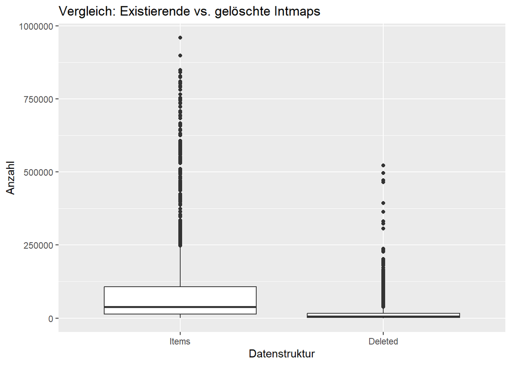

Zu erkennen ist, dass während der Problembearbeitung Intmaps nur selten gelöscht werden. Im Durchschnitt wird **18807.1330** gelöscht, wobei der Median nur **5943** und der Modus **1** beträgt. Die meisten Löschungen waren **522221**. Es gab auch Fälle in denen keine Intmaps gelöscht wurden.

#### 3.1.1 Verteilung der Anlage der Intmaps

Unten die Verteilung der Anlagen auf die einzelnen Datenstrukturen. Dabei werden Integer gesondert betrachtet, da diese die Auswertung verzerren würden:

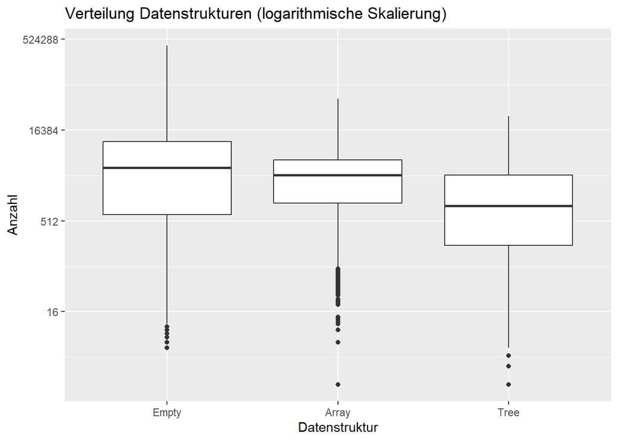

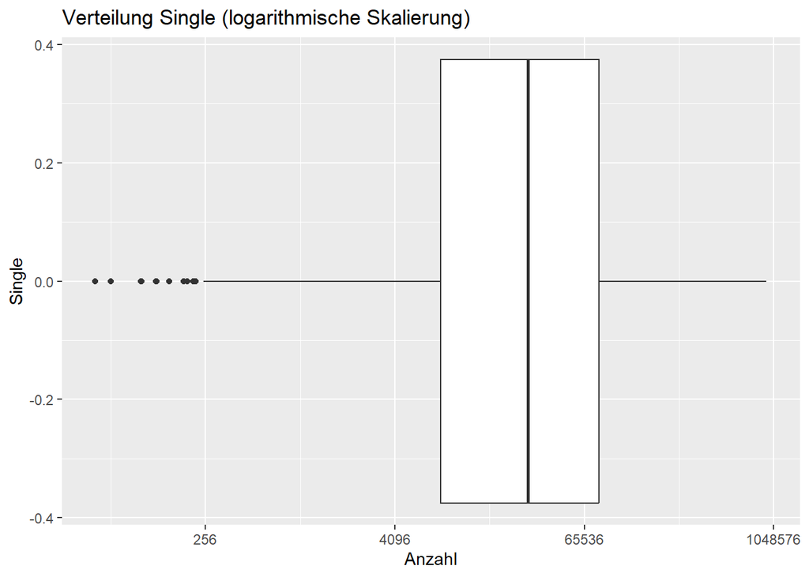

Intmaps vom Typ IMSingle werden am häufigsten angelegt, gefolgt von IMEMpty und auf Platz 3 IMArray. Schlusslicht bildet IMTree. Dabei ergeben sich folgende Verhältnisse:

**IMSingle** wird im Durschnitt **121.858537** und im Median **9.9457957** häufiger aufgerufen als **IMEmpty**. Wobei das niedrigste Verhältnis bei **0.0597197** und das höchste Verhältnis **28162.1111** bei liegt.

**IMSingle** wird im Durschnitt **20.1536416** und im Median **9.4690093** häufiger aufgerufen als **IMArray**. Wobei das niedrigste Verhältnis bei **0.9621535** und das höchste Verhältnis **1718.5833** bei liegt.

**IMSingle** wird im Durschnitt **466.6196078** und im Median **25.4115764** häufiger aufgerufen als **IMTree**. Wobei das niedrigste Verhältnis bei **3.7298507** und das höchste Verhältnis **73450.0000** bei liegt.

Anzahl wie oft kein Array angelegt wird: 1 Anzahl wie oft kein Baum angelegt wird: 9

**Vergleich zwischen IMArray und IMTree**

Hier ein Vergleich zwischen **IMArray** und **IMTree** folgt im nächsten Oberabschnitt.

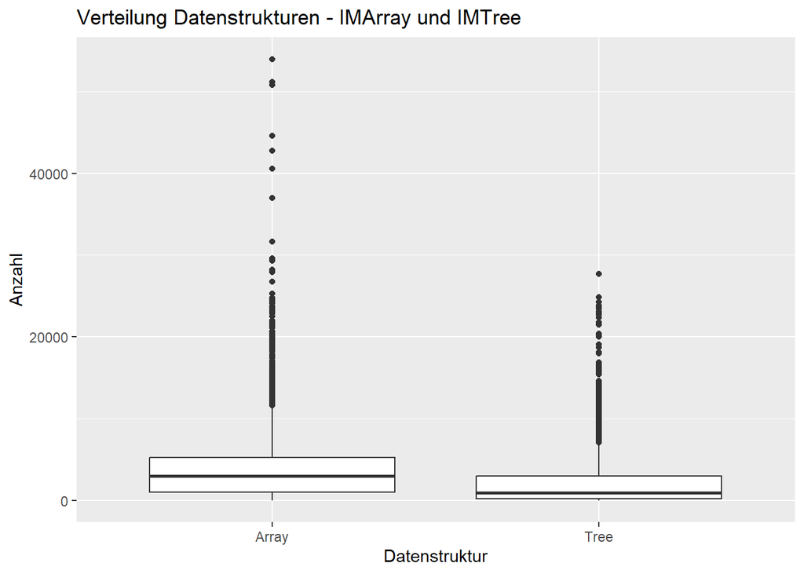

**IMArray** wird im Durschnitt **17.0322165** und im Median **2.7143928** häufiger aufgerufen als IMTree. Wobei das niedrigste Verhältnis bei **0** und das höchste Verhältnis **9213.0000** bei liegt.

#### 3.1.2 Verteilung der Löschung der Intmaps

Nun soll noch die Verteilung der Löschungen auf die einzelnen Datentypen betrachtet werden. Diesmal wird IMEmpty gesondert betrachtet werden:

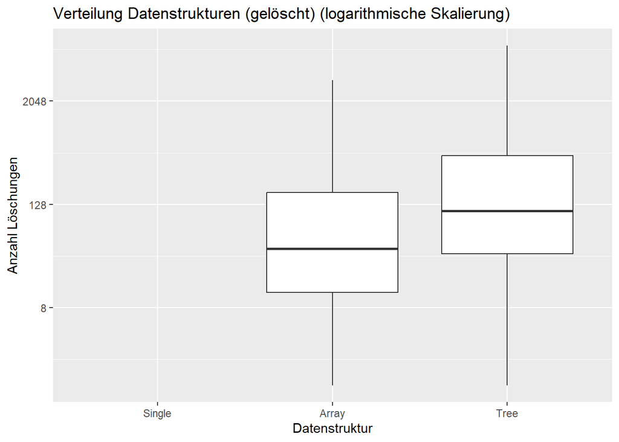

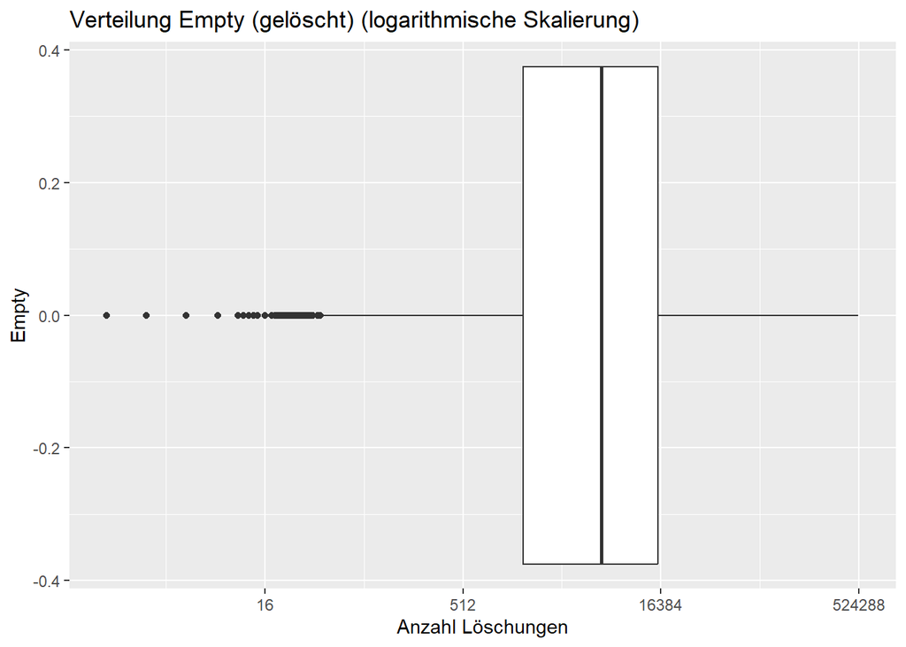

Klar zu sehen ist, dass IMEmpty am häufigsten gelöscht wird. In weiten Abstand folgen dann IMTree, IMArray und schließlich IMInteger. Es wird angenommen, dass häufiger zwischen IMArray und IMTree gewechselt wird, aber im Schnitt eher zur Anlage von IMArray tendiert wird - die Intmaps also meist recht dicht sind.

Am seltensten wurde **IMTree 0** und am häufigsten **9098** gelöscht. Im Durschnitt **410.3572** und im Median **97**. Der Modus beträgt **0**.

Am seltensten wurde **IMArray 0** und am häufigsten **3589** gelöscht. Im Durschnitt **143.3881** und im Median **32**. Der Modus beträgt **0**.

IMInteger wird nie gelöscht.

Zu erkennen ist also, dass das Löschen von Intmaps seltener vorkommt und in vielen Fällen so gut wie gar nicht geschiet während der Problemverarbeitung.

**Korrelation Größe und Löschung**

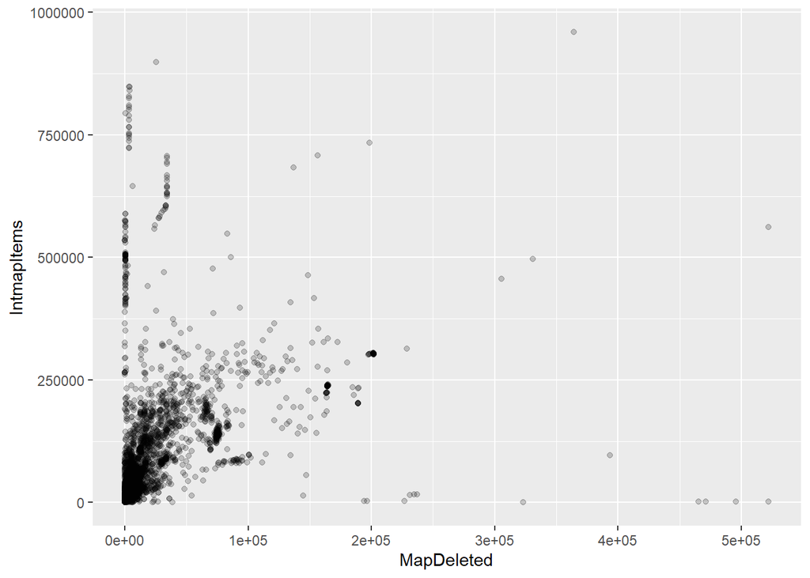

Es ist zu sehen, dass es einen leichten Zusammenhang zwischen der Intmap-Anzahl und der Anzahl der Löschungen gibt. Das war aber zu erwarten.

### 3.2 Zeitliche Abhängigkeiten

Die Bearbeitung der meisten Probleme wurde mit dem Soft-CPU-Limit mit 60 Sekunden beendet und würden länger laufen, wenn sie nicht unterbrochen worden wären.

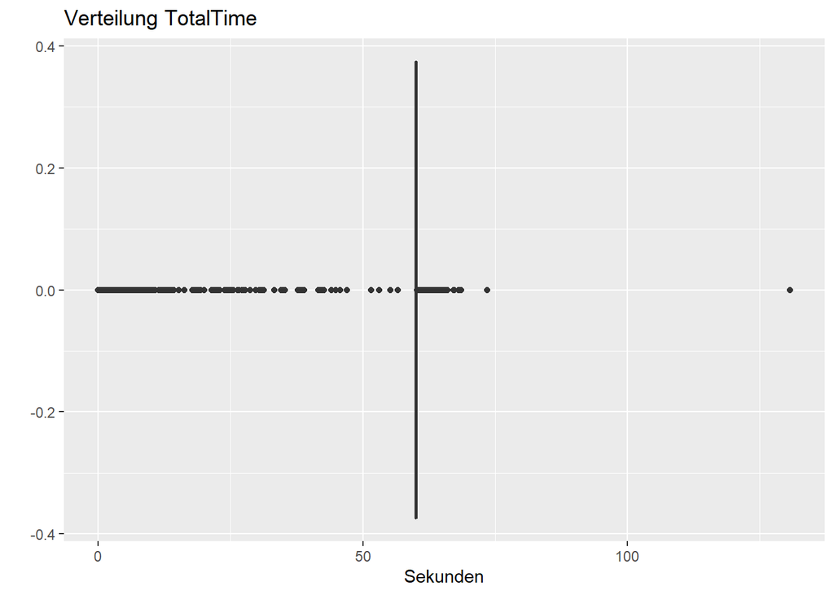

Damit wenig aussagekräftig, weshalb die Verteilung noch einmal eingehender untersucht werden soll für den Zeitraum zw. 0 und 55 Sekunden und den Zeitraum von 60 bis 65 Sekunden:

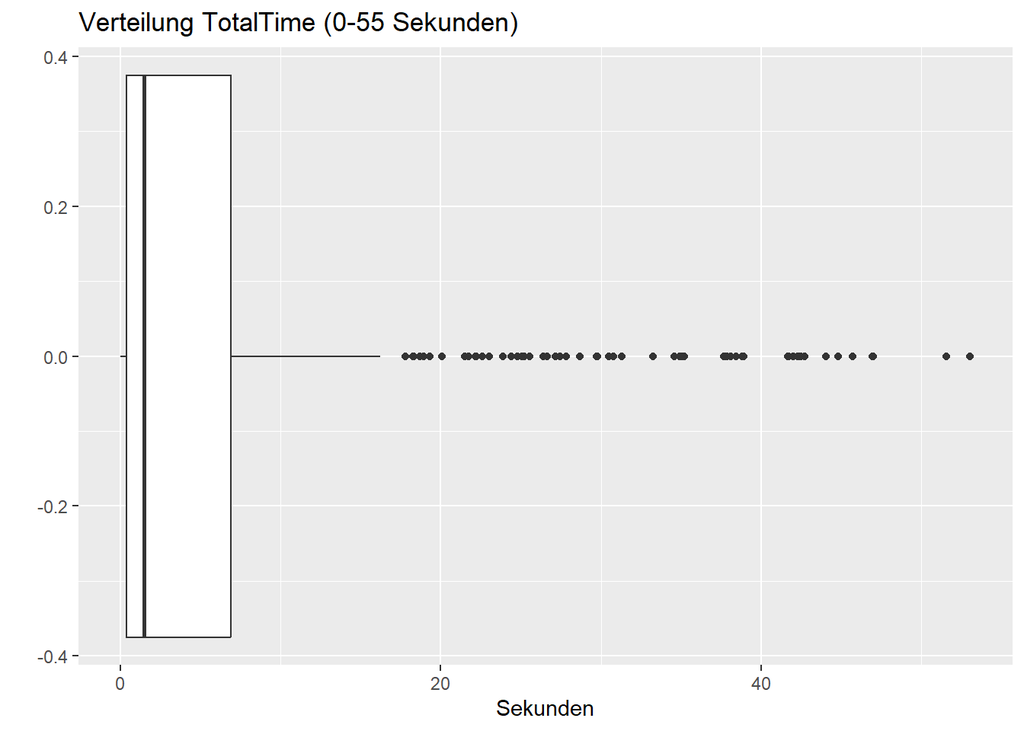

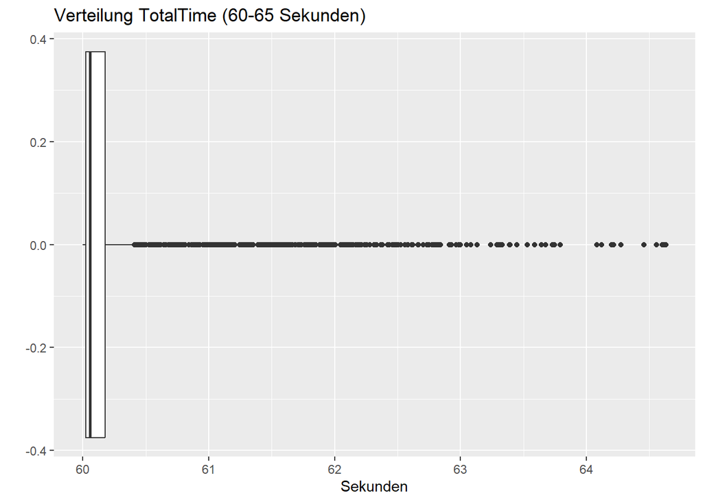

#### 3.2.1 Korrelation zwischen Zeit und Anlage der Intmaps

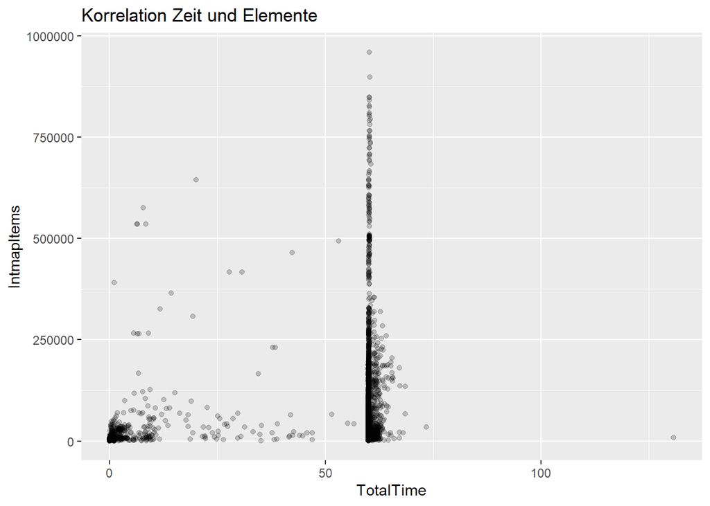

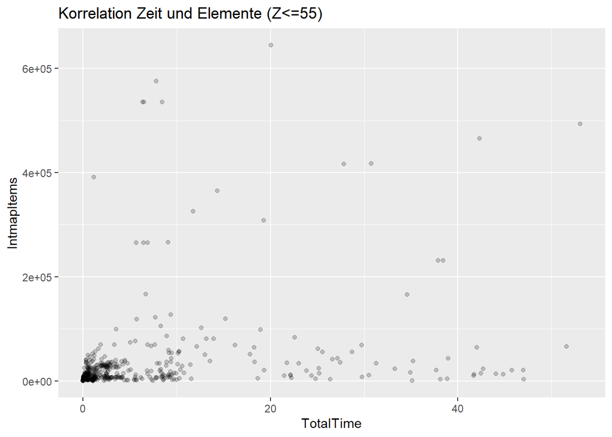

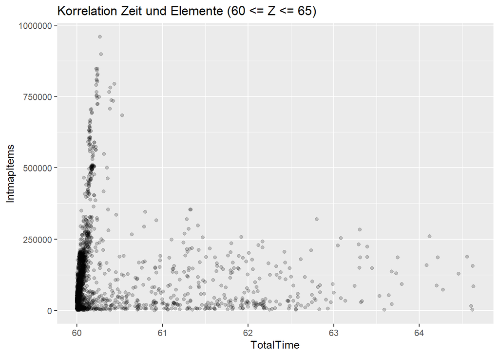

Eine wirkliche Korrelation zwischen Zeit und Anzahl der Intmap-Anlagen kann nicht festgestellt werden. Auch Probleme welche in den ersten 10 Sekunden gelöst werden, können sehr viele Intmaps anlegen und umgekehrt können Probleme, welche nicht in den ersten 10 Sekunden gelöst werden, recht wenige Intmaps anlegen. Meist bleibt dies im Bereich zwischen 0-100 000 Intmaps, auch für Probleme, welche nach den 60 Sekunden des Soft-CPU-Limits gelöst/nachbearbeitet werden gilt dieser Bereich. Auffällig sind die Peaks bei 60 Sekunden. Es handelt sich hierbei wohl um die wirklich langläufigen Probleme.

#### 3.2.2 Korrelation zwischen Zeit und Löschung der Intmaps

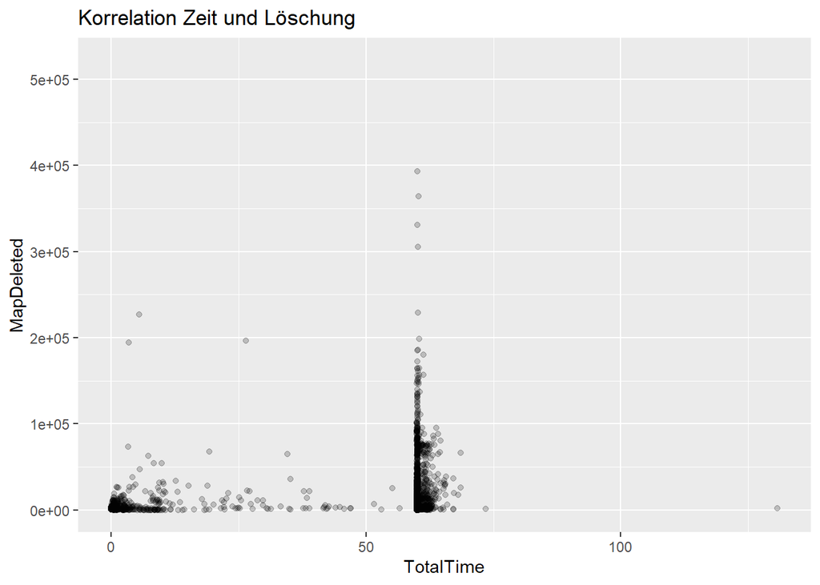

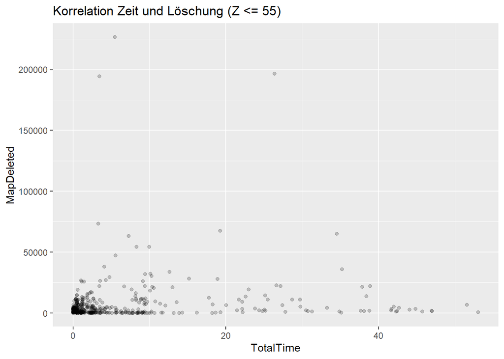

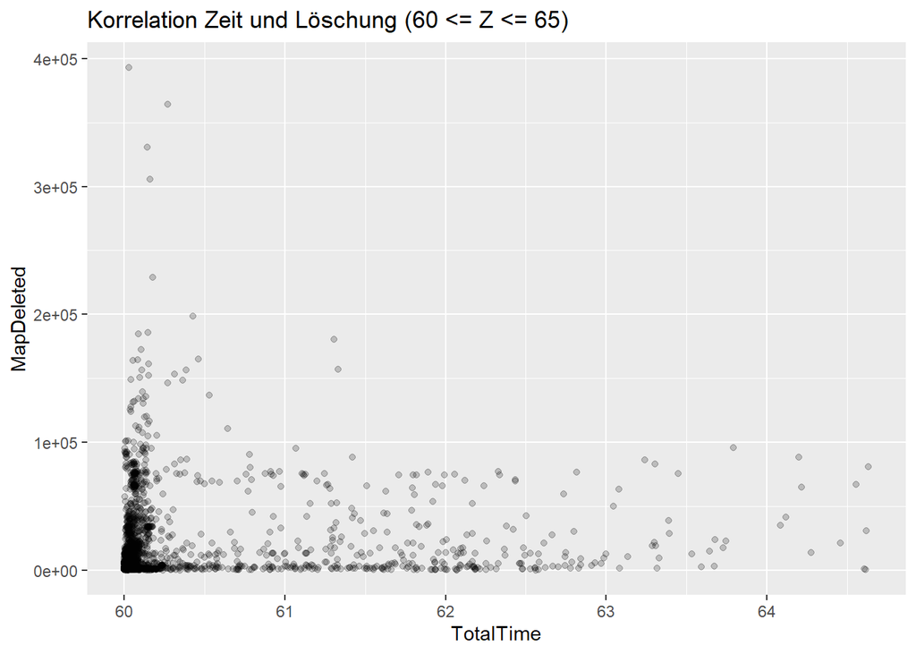

Ähnlich wie oben.

## Tiefere Untersuchung: IMArray und IMTree

In diesem Abschnitt sollen IMArray und IMTree genauer untersucht und miteinander verglichen werden. Aufgrund der Größe der eingelesenen Datensätze wurden diese in einer gesonderten Datei (big_file_converter.R) bereinigt und im komprimierten RDS-Format abgespeichert.

### IMArray

Hier eine Übersicht der allgemeinen statistischen Werte für IMArray

```
##     EntryNo              MinKey             MaxKey             Offset
##  Min.   :    0.000   Min.   :    -1.0   Min.   :    -1.0   Min.   :    -9
##  1st Qu.:    2.000   1st Qu.:     0.0   1st Qu.:     2.0   1st Qu.:    -4
##  Median :    2.000   Median :     1.0   Median :    11.0   Median :     0
##  Mean   :    3.906   Mean   :   186.8   Mean   :   361.5   Mean   :   144
##  3rd Qu.:    3.000   3rd Qu.:    28.0   3rd Qu.:    55.0   3rd Qu.:    23
##  Max.   :20279.000   Max.   :253054.0   Max.   :342959.0   Max.   :253054
##
##       Size           CountGetVal        CountGetRef       CountAssign
##  Min.   :     8.0   Min.   :       0   Min.   :      2   Min.   :   0.000
##  1st Qu.:     8.0   1st Qu.:       3   1st Qu.:      2   1st Qu.:   0.000
##  Median :    16.0   Median :      10   Median :      2   Median :   2.000
##  Mean   :   223.3   Mean   :    2717   Mean   :     84   Mean   :   1.235
##  3rd Qu.:    32.0   3rd Qu.:      50   3rd Qu.:      4   3rd Qu.:   2.000
##  Max.   :342968.0   Max.   :44750199   Max.   :4296850   Max.   :2930.000
##
##   CountDelKey      CountArrayToTree    CountTreeToArray    NumberOfItems
##  Min.   :    0.0   Min.   :    0.000   Min.   :    0.000   Min.   :    0.000
##  1st Qu.:    0.0   1st Qu.:    0.000   1st Qu.:    0.000   1st Qu.:    2.000
##  Median :    0.0   Median :    0.000   Median :    0.000   Median :    2.000
##  Mean   :    0.2   Mean   :    0.027   Mean   :    0.041   Mean   :    3.906
##  3rd Qu.:    0.0   3rd Qu.:    0.000   3rd Qu.:    0.000   3rd Qu.:    3.000
##  Max.   :16780.0   Max.   :13770.000   Max.   :13770.000   Max.   :20279.000
##
##  NumberOfEmptyCells    MinNode            MaxNode         MinMaxDistance
##  Min.   :     0.0   Min.   :    -1.0   Min.   :    -1.0   Min.   :     0.0
##  1st Qu.:     6.0   1st Qu.:     0.0   1st Qu.:     2.0   1st Qu.:     1.0
##  Median :    13.0   Median :     1.0   Median :    11.0   Median :     2.0
##  Mean   :   219.4   Mean   :   186.8   Mean   :   361.5   Mean   :   174.6
##  3rd Qu.:    30.0   3rd Qu.:    28.0   3rd Qu.:    55.0   3rd Qu.:    13.0
##  Max.   :342965.0   Max.   :253054.0   Max.   :342959.0   Max.   :341382.0
##
##     Density
##  Min.   :0.0000
##  1st Qu.:0.1250
##  Median :0.2000
##  Mean   :0.1944
##  3rd Qu.:0.2500
##  Max.   :1.0000
##  NA's   :6
```

Size # All; 1-3; 3. Quartil betrachten

CountAssign > 2 # 3. Quartil betrachten

CountDelKey > 0 # 3. Quartil betrachten

CountArrayToTree > 0 # 3. Quartil betrachten

CountTreeToArray > 0 # 3. Quartil betrachten

NumberOfItems > 3 # 3. Quartil betrachten

### Vergleich zwischen IMArray und IMTree

#### IMArray

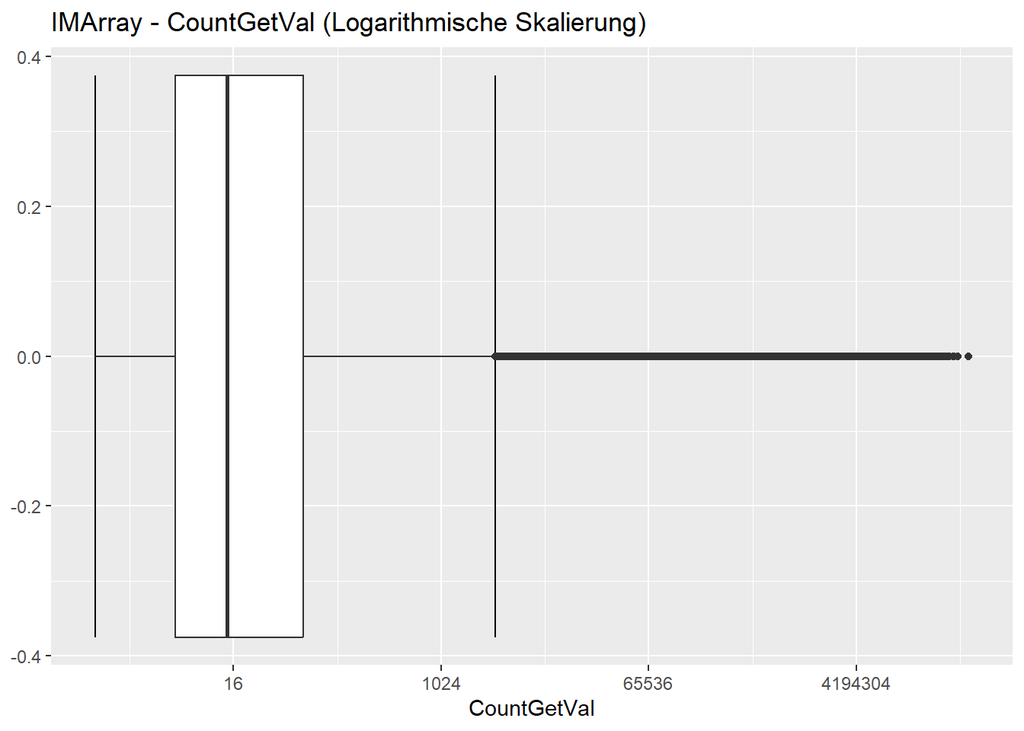

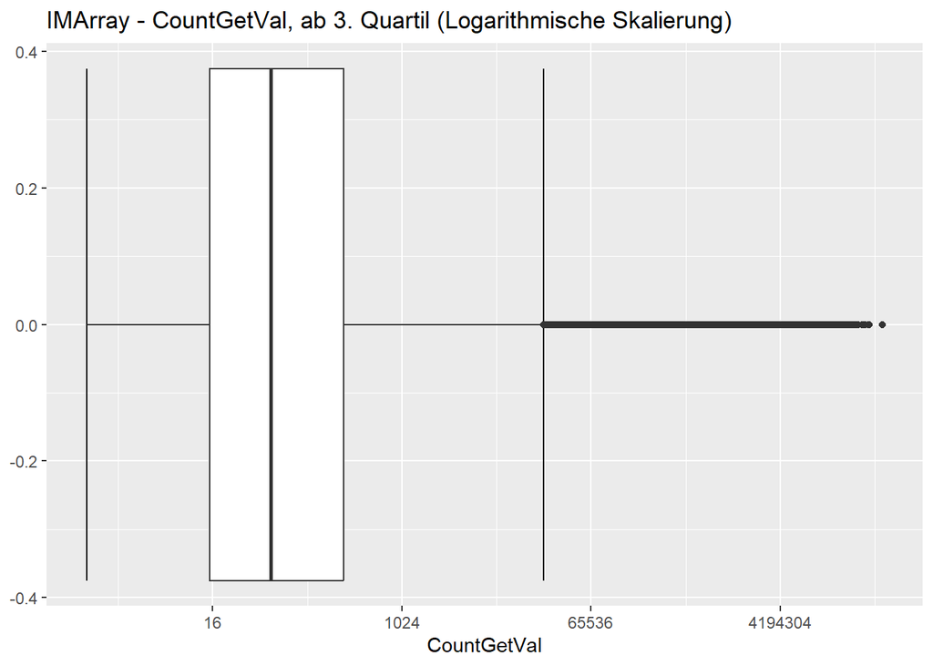

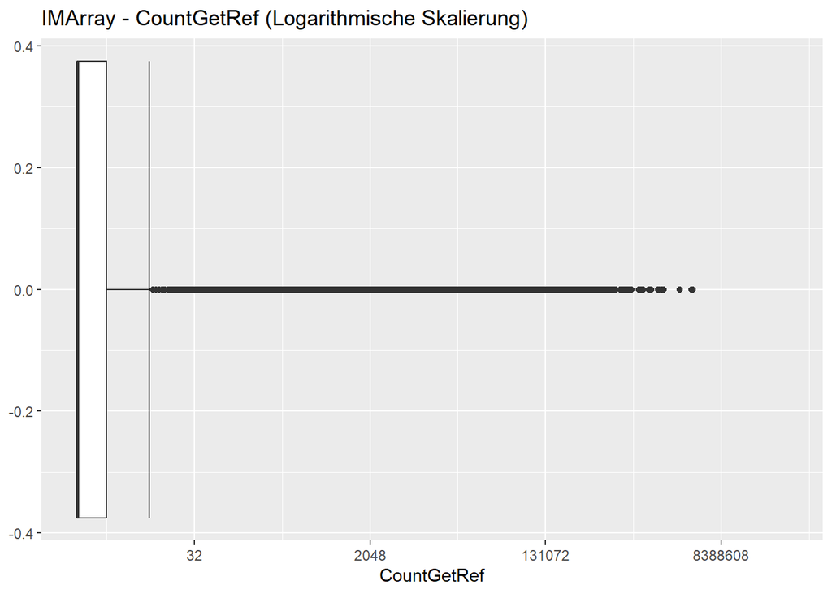

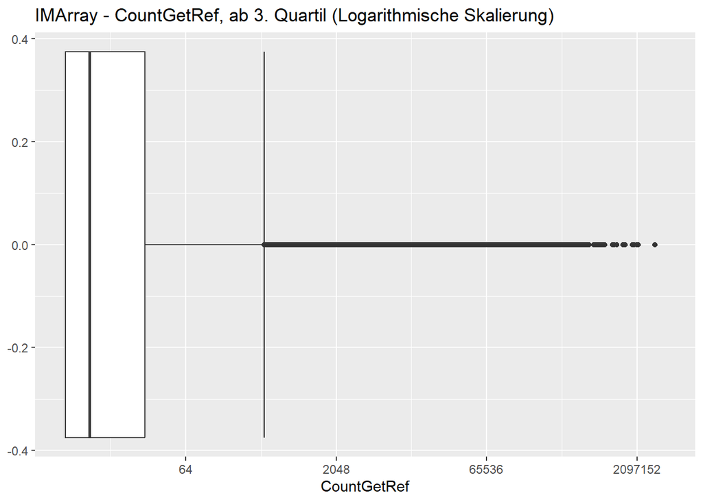

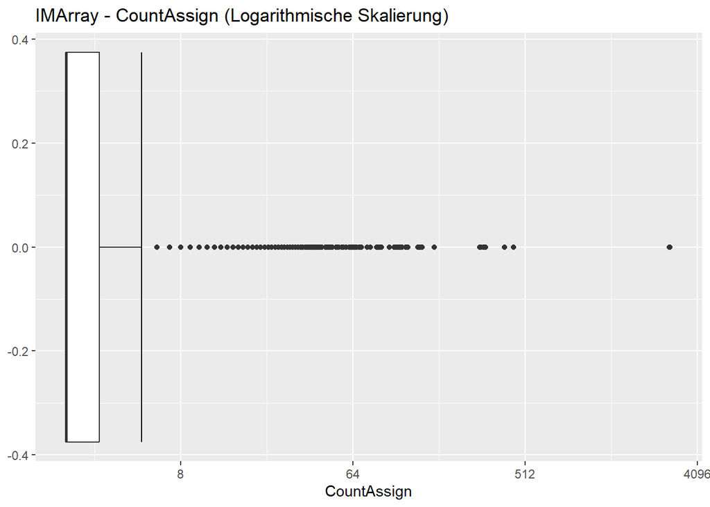

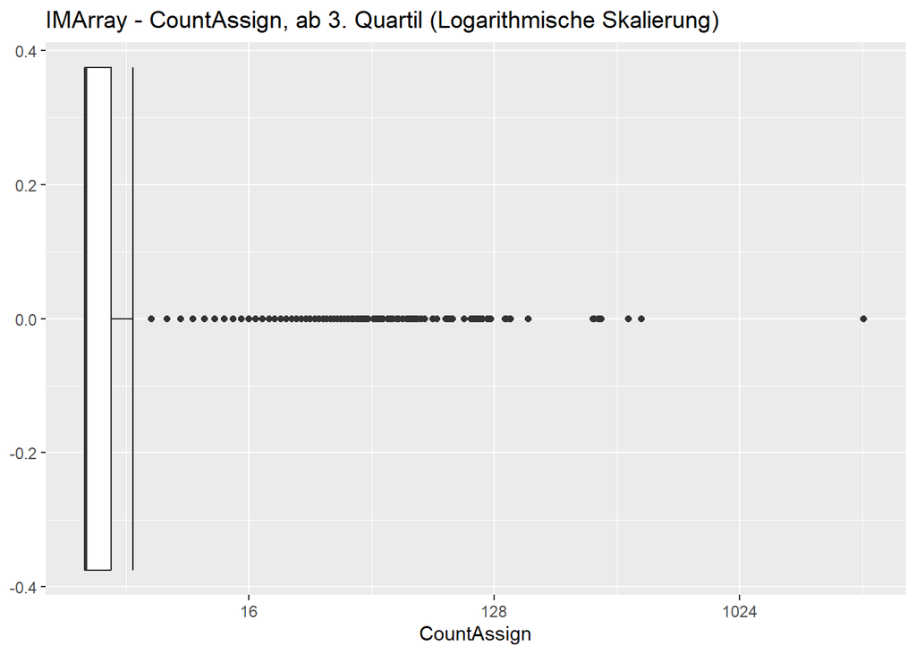

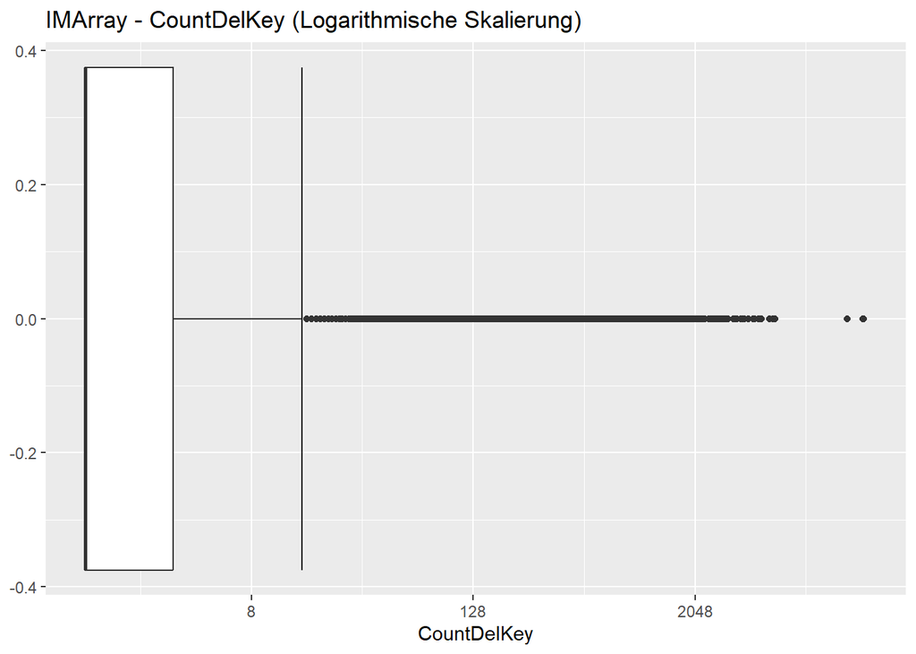

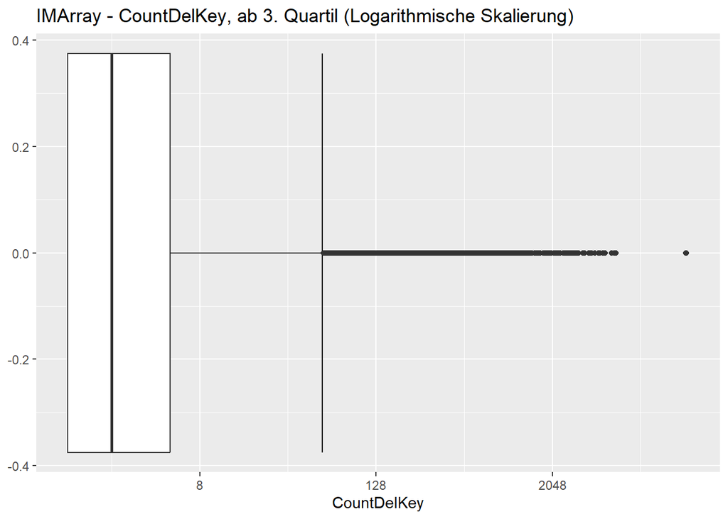

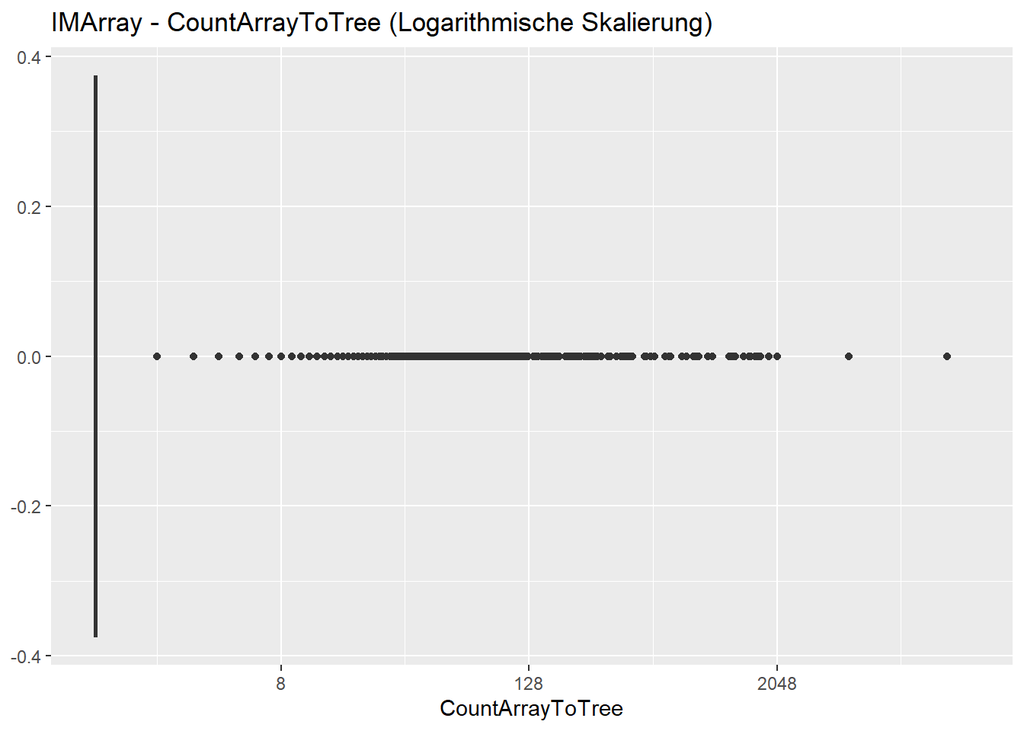

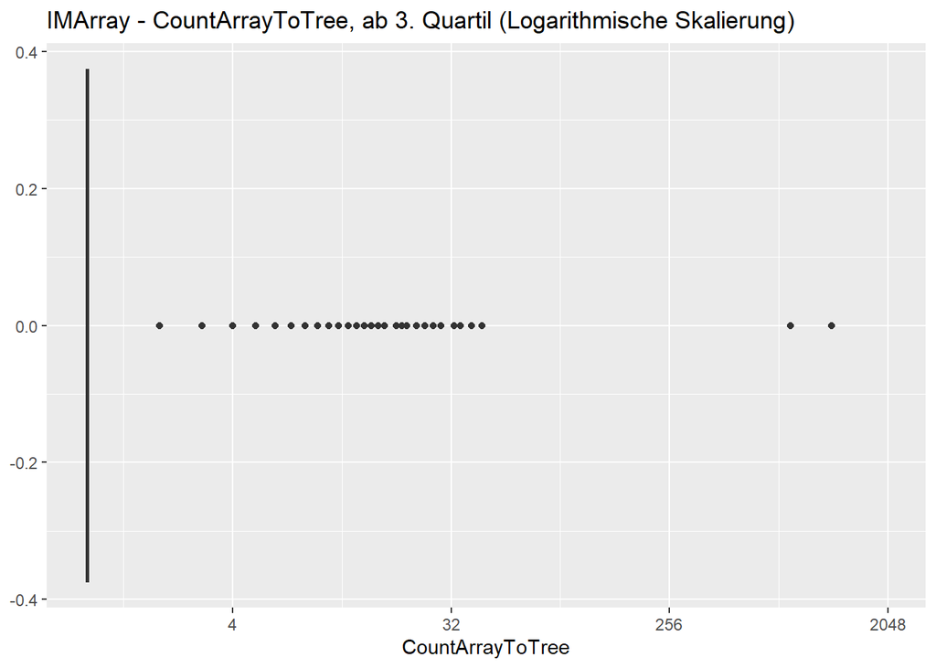

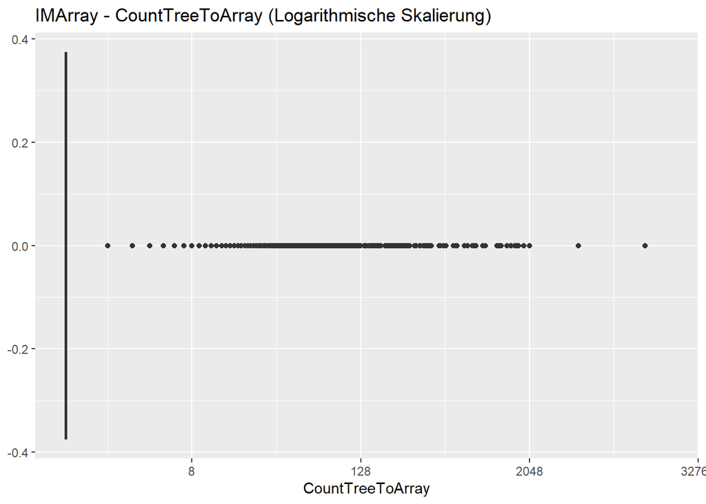

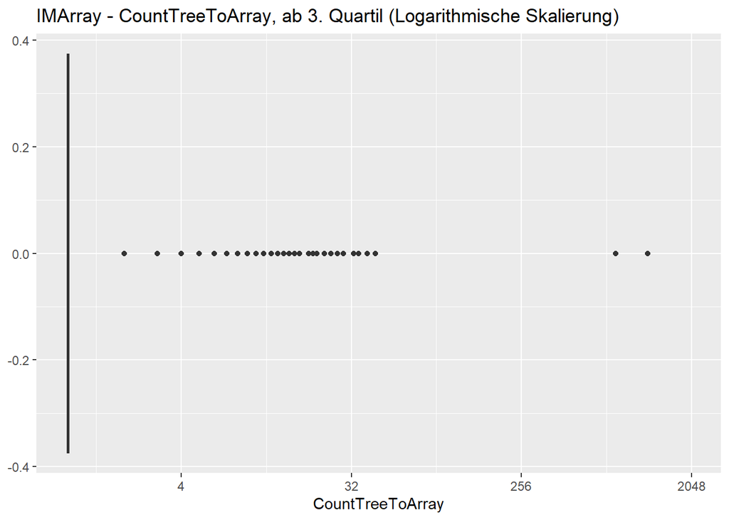

[6 more figures not shown]